# Linear Models

Ma Tingting

Trepça Frida

Unni Narayanan Adhithya

Valdés Aharon

Sander Schoepen

2022-12-28

## Salary gender discrimination

A group of researchers were interested in whether or not there is gender discrimination with respect to employee salaries at a particular firm. To that end a random sample of 132 employees was studied. The researchers collected information on gender, salary and educational level. The final data set Contained the following variables

Gender: A binary variable taking values Female and Male Salary: Salary perceived in thousands of dollars per year Education: A binary variable taking values Degree and No degree

#### Asigment 1:

Refer to the Salary gender discrimination data set. Assume that the sample sizes do not reflect the importance of the treatment means. Carry out an unbalanced two-way analysis of variance of this data set, where the response of interest is Salary and the two crossed factors Gender and Education.

#### Asigment 2:

Refer to the Salary gender discrimination data set. Assume that the sample sizes reflect the importance of the treatment means. Carry out an unbalanced two-way analysis of variance of this data set, where the response of interest is Salary and the two crossed factors Gender and Education.

Compare the results of both analyses and explain their similarities and differences in a formal and intuitive way. Discuss the appropriateness of the model.

### Note:

Students are encouraged to look for alternative analysis and techniques in the literature if models studied in the course are not appropriate to answer the scientific questions. The idea is to mimic the real work of a consulting statistician in the academia or the industry.

# 2 Checking DataSet

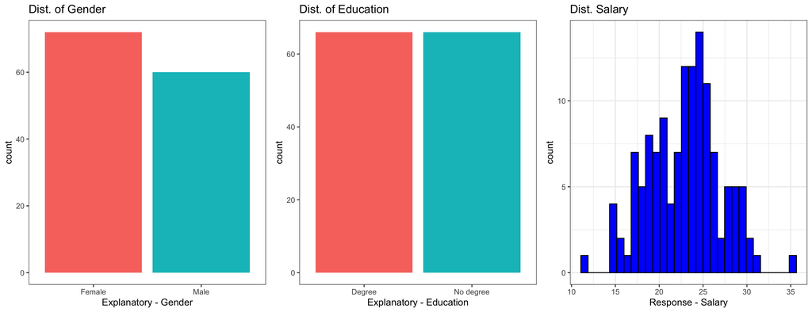

```r
#Exploratory Data Analysis

# Distribution of response variable - Salary
p_ht1 <- ggplot(salary.gender.txt01, aes(Salary)) +
  geom_histogram(colour = 'black', fill = 'blue', bins=30) +
  ggtitle('Dist. Salary') +
  xlab('Response - Salary') +
  theme_bw()

# Distribution of explanatory variable - f.gender
p_br1 <- ggplot(salary.gender.txt01, aes(f.gender, fill = f.gender)) +
  geom_bar() +
  ggtitle('Dist. of Gender') +
  xlab('Explanatory - Gender') +
  theme_bw()+
  theme(panel.grid = element_blank(), legend.position = 'none')

# Distribution of explanatory variable - f.education
p_br2 <- ggplot(salary.gender.txt01, aes(f.education, fill = f.education)) +
  geom_bar() +
  theme(axis.text.x=element_blank())  +
  ggtitle('Dist. of Education') +
  xlab('Explanatory - Education') +
  theme_bw()+
  theme(panel.grid = element_blank(), legend.position = 'none')
grid.arrange(p_br1, p_br2,p_ht1, ncol = 3)
```

### 2.2 Mean of response variable

```r
table_unbal_mean <- with(salary.gender.txt01,
                         tapply(Salary, list(f.gender, f.education), mean))

table_unbal_mean %>% round(2) %>% as.table()
```

```
##        Degree No degree
## Female  24.81     18.28
## Male    27.30     21.44
```

```r
# Frequency table of response variable by gender, education and salary
table_unbal_freq <- with(salary.gender.txt01,
                         table(f.gender, f.education))
table_unbal_freq
```

```
##         f.education
## f.gender Degree No degree
##   Female     48        24
##   Male       18        42
```

```r
# Data in long format
data_longer <- table_unbal_mean %>% as.data.frame()
data_longer$`f.gender` <- row.names(data_longer)
data_longer <- data_longer %>%
  pivot_longer(cols = c(Degree, `No degree`),
               names_to = 'degree',
               values_to = 'mean_y')
data_longer
```

```
## # A tibble: 4 × 3
##   f.gender degree    mean_y
##   <chr>    <chr>      <dbl>
## 1 Female   Degree      24.8
## 2 Female   No degree   18.3
## 3 Male     Degree      27.3
## 4 Male     No degree   21.4
```

### 2.3.1 Interaction

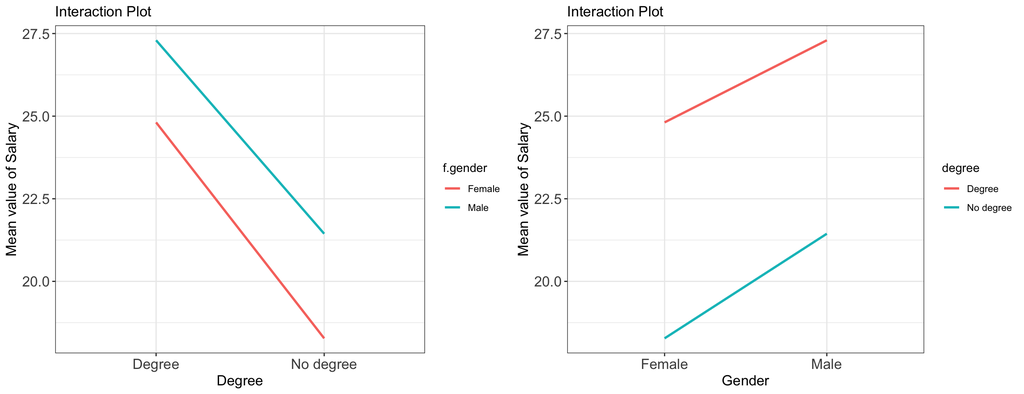

```r
#with(salary.gender.txt01, interaction.plot(
#  x.factor = Education,
#  trace.factor = Gender,
#  response = Salary,
#  fun = mean, type = "b", legend = T,ylab = "Mean Salary",
#                                main="Interaction plot", pch=c(1,19)))

int1 <- ggplot(data_longer, aes(degree, mean_y)) +
  geom_line(aes(group = f.gender, color = f.gender), size = 1) +
  xlab('Degree') +
  ylab('Mean value of Salary') +
  ggtitle('Interaction Plot') +
  theme_bw() +
  theme(axis.text.y = element_text(size = 13),
        axis.title.y = element_text(size = 13),
        axis.text.x = element_text(size = 13),
        axis.title.x = element_text(size = 13))

int2 <- ggplot(data_longer, aes(f.gender, mean_y)) +
  geom_line(aes(group = degree, color = degree), size = 1) +
  xlab('Gender') +
  ylab('Mean value of Salary') +
  ggtitle('Interaction Plot') + theme_bw() +
  theme(axis.text.y = element_text(size = 13),
        axis.title.y = element_text(size = 13),
        axis.text.x = element_text(size = 13),
        axis.title.x = element_text(size = 13))

grid.arrange(int1, int2, ncol = 2)
```

### 2.3.2 Interaction BoxPlot

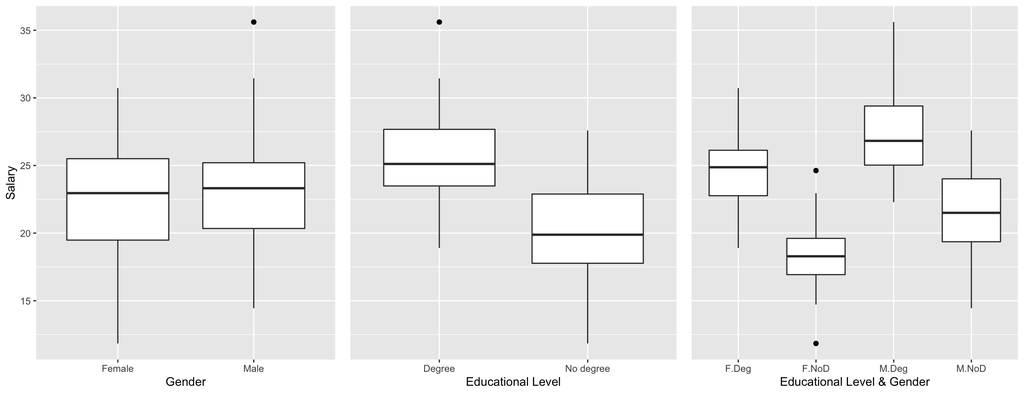

```r
salary.gender.txt01$EdDe <- interaction(
  salary.gender.txt01$Gender,
  salary.gender.txt01$Education)

salary.gender.txt01$EdDe <- ifelse(
  salary.gender.txt01$EdDe=='Male.No degree','M.NoD',
    ifelse(salary.gender.txt01$EdDe=='Male.Degree','M.Deg',
           ifelse(salary.gender.txt01$EdDe=='Female.No degree','F.NoD','F.Deg'))
)

bxp1 <- ggplot(salary.gender.txt01, aes(f.gender, y = Salary)) +
geom_boxplot(outlier.colour="black", outlier.shape=16,
             outlier.size=2, notch=FALSE) +
  xlab('Gender')

bxp2 <- ggplot(salary.gender.txt01, aes(f.education, y = Salary)) +
  geom_boxplot(outlier.colour="black", outlier.shape=16,
               outlier.size=2, notch=FALSE) +
   xlab('Educational Level') +
  theme(axis.text.y=element_blank(),
    axis.title.y.left = element_blank(),
    axis.ticks.y=element_blank())


bxp3 <- ggplot(salary.gender.txt01, aes(EdDe, y = Salary)) +
  geom_boxplot(outlier.colour="black", outlier.shape=16,
               outlier.size=2, notch=FALSE) +
  xlab('Educational Level & Gender') +
  theme(axis.text.y=element_blank(),
    axis.title.y.left = element_blank(),
    axis.ticks.y=element_blank())


grid.arrange(bxp1, bxp2, bxp3, ncol = 3)
```

```r
#boxplot(Salary~Gender, col=0, data = salary.gender.txt01)
#boxplot(Salary~Education, col=0, data=salary.gender.txt01)
#boxplot(Salary~Gender*Education, col=0, data=salary.gender.txt01,
#        main="Boxplots of Salaries Data")
```

# 3 Assumptions

Check the assumptions: Two-way ANOVA assumes that the data are normally distributed and homoscedastic (i.e., the variances of the groups are equal). Use statistical tests or plots to check whether these assumptions are met.

### Normally Distributed

```r
salaries.fit<-aov(Salary~Gender*Education,data=salary.gender.txt01)
salaries.fit.summary<-summary(salaries.fit)
salaries.fit.summary
```

```
##                   Df Sum Sq Mean Sq F value Pr(>F)
## Gender             1   10.5    10.5   1.224  0.271
## Education          1 1112.1  1112.1 130.000 <2e-16 ***
## Gender:Education   1    3.3     3.3   0.383  0.537
## Residuals        128 1095.0     8.6
## ---
## Signif. codes:  0 '***' 0.001 '**' 0.01 '*' 0.05 '.' 0.1 ' ' 1
```

```r
 ## Normality by Shapiro-Wilk
shapiro.test(residuals(salaries.fit))
```

```
##
##  Shapiro-Wilk normality test
##
## data:  residuals(salaries.fit)
## W = 0.99563, p-value = 0.9614
```

```r
#residuals(salaries.fit)
ks.test(residuals(salaries.fit),"pnorm", alternative="two.sided")
```

```
##
##  One-sample Kolmogorov-Smirnov test
##
## data:  residuals(salaries.fit)
## D = 0.25711, p-value = 5.267e-08
## alternative hypothesis: two-sided
```

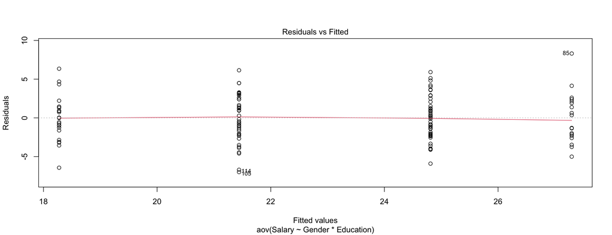

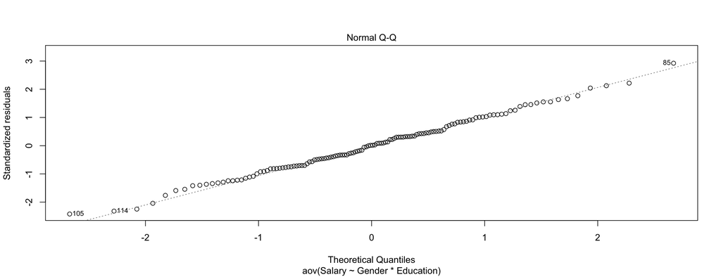

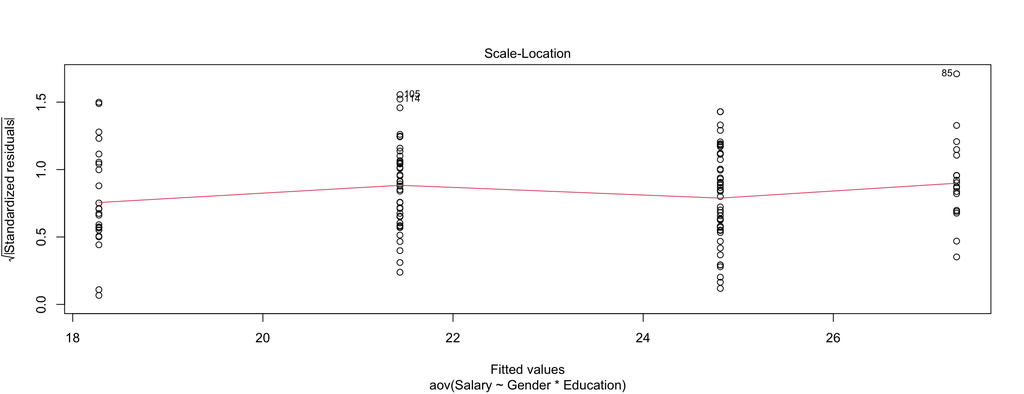

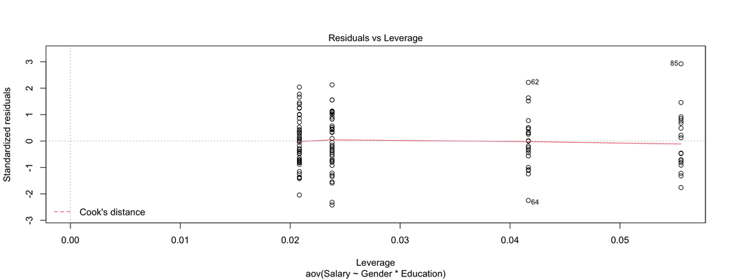

```r
plot(salaries.fit)
```

## Fit Anova

```r
#salaries.fit<-aov(Salary~Gender*Education,data=salary.gender.txt01)
#salaries.fit.summary<-summary(salaries.fit)
#salaries.fit.summary
```

No evidence for an interaction effect.

comparison using Tukey procedure

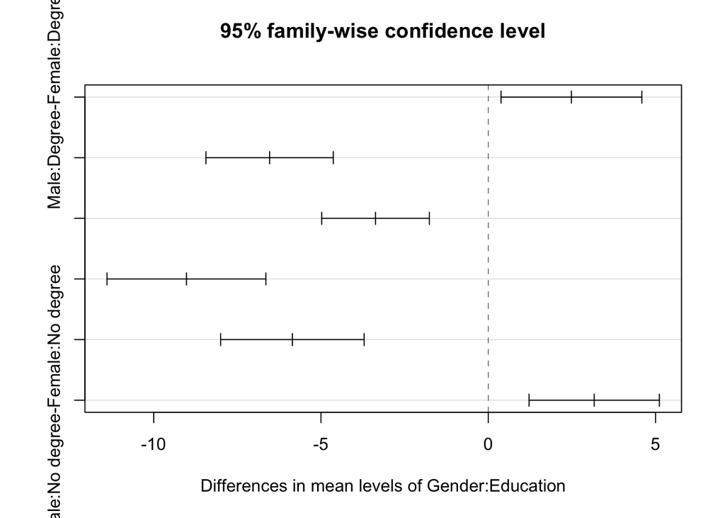

```r
salaries.fit.tukey<-TukeyHSD(salaries.fit,which=c("Gender:Education"),conf.level = .95)
plot(salaries.fit.tukey)
```

```r
salaries.fit.tukey
```

```
##   Tukey multiple comparisons of means
##     95% family-wise confidence level
##
## Fit: aov(formula = Salary ~ Gender * Education, data = salary.gender.txt01)
##
## $`Gender:Education`
##                                      diff         lwr       upr     p adj
## Male:Degree-Female:Degree        2.485193   0.3808626  4.589524 0.0135852
## Female:No degree-Female:Degree  -6.536031  -8.4394704 -4.632592 0.0000000
## Male:No degree-Female:Degree    -3.369498  -4.9781975 -1.760798 0.0000015
## Female:No degree-Male:Degree    -9.021225 -11.3952304 -6.647219 0.0000000
## Male:No degree-Male:Degree      -5.854691  -7.9996242 -3.709759 0.0000000
## Male:No degree-Female:No degree  3.166533   1.2183015  5.114765 0.0002550
```

Fit a two-way anova model without interaction effects

```r
salaries.fit_2<-aov(Salary~Gender+Education,data=salary.gender.txt01)
salaries.fit_2.summary<-summary(salaries.fit_2)
salaries.fit_2.summary
```

```
##              Df Sum Sq Mean Sq F value Pr(>F)
## Gender        1   10.5    10.5    1.23   0.27
## Education     1 1112.1  1112.1  130.62 <2e-16 ***
## Residuals   129 1098.3     8.5
## ---
## Signif. codes:  0 '***' 0.001 '**' 0.01 '*' 0.05 '.' 0.1 ' ' 1
```

### Type I SS

```r
type1.unbalanced1<-aov(Salary~Gender*Education,data = salary.gender.txt01)
type1.unbalanced1.summary<-summary(type1.unbalanced1)
type1.unbalanced1.summary #only Education failed null-hypothesis
```

```
##                   Df Sum Sq Mean Sq F value Pr(>F)
## Gender             1   10.5    10.5   1.224  0.271
## Education          1 1112.1  1112.1 130.000 <2e-16 ***
## Gender:Education   1    3.3     3.3   0.383  0.537
## Residuals        128 1095.0     8.6
## ---
## Signif. codes:  0 '***' 0.001 '**' 0.01 '*' 0.05 '.' 0.1 ' ' 1
```

```r
type1.unbalanced2<-aov(Salary~Education*Gender,data = salary.gender.txt01)
type1.unbalanced2.summary<-summary(type1.unbalanced2)
type1.unbalanced2.summary #both Education and Gender failed null-hypothesis
```

```
##                   Df Sum Sq Mean Sq F value   Pr(>F)
## Education          1  891.9   891.9 104.255  < 2e-16 ***
## Gender             1  230.7   230.7  26.969 7.91e-07 ***
## Education:Gender   1    3.3     3.3   0.383    0.537
## Residuals        128 1095.0     8.6
## ---
## Signif. codes:  0 '***' 0.001 '**' 0.01 '*' 0.05 '.' 0.1 ' ' 1
```

### Type II SS

```r
type2.unbalanced<-Anova(lm(Salary~Gender*Education,data = salary.gender.txt01,
                           contrasts=list(Gender="contr.sum", Education="contr.sum")), type="II")
type2.unbalanced #both Education and Gender failed null-hypothesis
```

```
## Anova Table (Type II tests)
##
## Response: Salary
##                   Sum Sq  Df  F value    Pr(>F)
## Gender            230.72   1  26.9691 7.912e-07 ***
## Education        1112.14   1 130.0001 < 2.2e-16 ***
## Gender:Education    3.27   1   0.3825    0.5374
## Residuals        1095.03 128
## ---
## Signif. codes:  0 '***' 0.001 '**' 0.01 '*' 0.05 '.' 0.1 ' ' 1
```

### Type III SS

```r
type3.unbalanced<-Anova(lm(Salary~Gender*Education,data = salary.gender.txt01,contrasts=list(Gender="contr.sum", Education="contr.sum")), type="III")
type3.unbalanced #both Education and Gender failed null-hypothesis
```

```
## Anova Table (Type III tests)
##
## Response: Salary
##                  Sum Sq  Df   F value    Pr(>F)
## (Intercept)       59436   1 6947.5705 < 2.2e-16 ***
## Gender              225   1   26.3191 1.045e-06 ***
## Education          1082   1  126.5035 < 2.2e-16 ***
## Gender:Education      3   1    0.3825    0.5374
## Residuals          1095 128
## ---
## Signif. codes:  0 '***' 0.001 '**' 0.01 '*' 0.05 '.' 0.1 ' ' 1
```

### Decision

Type I, II or III decision * Type III will be used * No significant interaction between Gender and Education.

### Factor Effect Model

```r
data <- salary.gender.txt01
data$Gender <- as.factor(data$Gender)
data$Education <- as.factor(data$Education)
summary(data)
```

```
##      Salary         Gender       Education    f.gender     f.education
##  Min.   :11.84   Female:72   Degree   :66   Female:72   Degree   :66
##  1st Qu.:19.77   Male  :60   No degree:66   Male  :60   No degree:66
##  Median :23.02
##  Mean   :22.89
##  3rd Qu.:25.34
##  Max.   :35.61
##      EdDe
##  Length:132
##  Class :character
##  Mode  :character
##
##
##
```

```r
contrasts(data$Gender) = contr.sum
contrasts(data$Education) = contr.sum
model.matrix(~Gender*Education, data)
```

```
##     (Intercept) Gender1 Education1 Gender1:Education1
## 1             1       1          1                  1
## 2             1       1          1                  1
## 3             1       1          1                  1
## 4             1       1          1                  1
## 5             1       1          1                  1
## 6             1       1          1                  1
## 7             1       1          1                  1
## 8             1       1          1                  1
## 9             1       1          1                  1
## 10            1       1          1                  1
## 11            1       1          1                  1
## 12            1       1          1                  1
## 13            1       1          1                  1
## 14            1       1          1                  1
```

[output cut: 130 more lines]

### Creating the indicator variables

```r
data1 <- as.data.frame(model.matrix(~ Gender*Education, data, contrasts =
                                      list(Gender="contr.sum",Education="contr.sum"))[,2:4])
data1$Salary <-data$Salary
data1
```

```
##     Gender1 Education1 Gender1:Education1   Salary
## 1         1          1                  1 23.86384
## 2         1          1                  1 25.78549
## 3         1          1                  1 20.70476
## 4         1          1                  1 21.47234
## 5         1          1                  1 29.63171
## 6         1          1                  1 22.46636
## 7         1          1                  1 29.93721
## 8         1          1                  1 27.68114
## 9         1          1                  1 25.68616
## 10        1          1                  1 22.43882
## 11        1          1                  1 23.39381
## 12        1          1                  1 24.85205
## 13        1          1                  1 20.85213
## 14        1          1                  1 24.69347
```

[output cut: 118 more lines]

```r
data.full=lm(Salary ~ Gender1 + Education1 + Gender1:Education1, data = data1)
summary(data.full)
```

```
##
## Call:
## lm(formula = Salary ~ Gender1 + Education1 + Gender1:Education1,
##     data = data1)
##
## Residuals:
##     Min      1Q  Median      3Q     Max
## -6.9985 -2.0841  0.0374  1.9549  8.3104
##
## Coefficients:
##                    Estimate Std. Error t value Pr(>|t|)
## (Intercept)         22.9563     0.2754  83.352  < 2e-16 ***
## Gender1             -1.4129     0.2754  -5.130 1.05e-06 ***
## Education1           3.0977     0.2754  11.247  < 2e-16 ***
## Gender1:Education1   0.1703     0.2754   0.618    0.537
## ---
## Signif. codes:  0 '***' 0.001 '**' 0.01 '*' 0.05 '.' 0.1 ' ' 1
##
## Residual standard error: 2.925 on 128 degrees of freedom
## Multiple R-squared:  0.5069, Adjusted R-squared:  0.4954
## F-statistic: 43.87 on 3 and 128 DF,  p-value: < 2.2e-16
```

```r
data.reduced=lm(Salary ~ Gender1+ Education1, data = data1)
summary(data.reduced)
```

```
##
## Call:
## lm(formula = Salary ~ Gender1 + Education1, data = data1)
##
## Residuals:
##     Min      1Q  Median      3Q     Max
## -6.8841 -2.0049  0.0337  1.7972  8.0436
##
## Coefficients:
##             Estimate Std. Error t value Pr(>|t|)
## (Intercept)  23.0194     0.2552  90.207  < 2e-16 ***
## Gender1      -1.4260     0.2739  -5.206 7.42e-07 ***
## Education1    3.1179     0.2728  11.429  < 2e-16 ***
## ---
## Signif. codes:  0 '***' 0.001 '**' 0.01 '*' 0.05 '.' 0.1 ' ' 1
##
## Residual standard error: 2.918 on 129 degrees of freedom
## Multiple R-squared:  0.5055, Adjusted R-squared:  0.4978
## F-statistic: 65.93 on 2 and 129 DF,  p-value: < 2.2e-16
```

### Test for the interaction

```r
anova(data.reduced, data.full) #no interaction
```

```
## Analysis of Variance Table
##
## Model 1: Salary ~ Gender1 + Education1
## Model 2: Salary ~ Gender1 + Education1 + Gender1:Education1
##   Res.Df    RSS Df Sum of Sq      F Pr(>F)
## 1    129 1098.3
## 2    128 1095.0  1    3.2723 0.3825 0.5374
```

### analysis of residuals

```r
salary.fit <- aov(Salary~Gender*Education, data = salary.gender.txt01)
summary(salary.fit) # null-hypothesis rejected
```

```
##                   Df Sum Sq Mean Sq F value Pr(>F)
## Gender             1   10.5    10.5   1.224  0.271
## Education          1 1112.1  1112.1 130.000 <2e-16 ***
## Gender:Education   1    3.3     3.3   0.383  0.537
## Residuals        128 1095.0     8.6
## ---
## Signif. codes:  0 '***' 0.001 '**' 0.01 '*' 0.05 '.' 0.1 ' ' 1
```

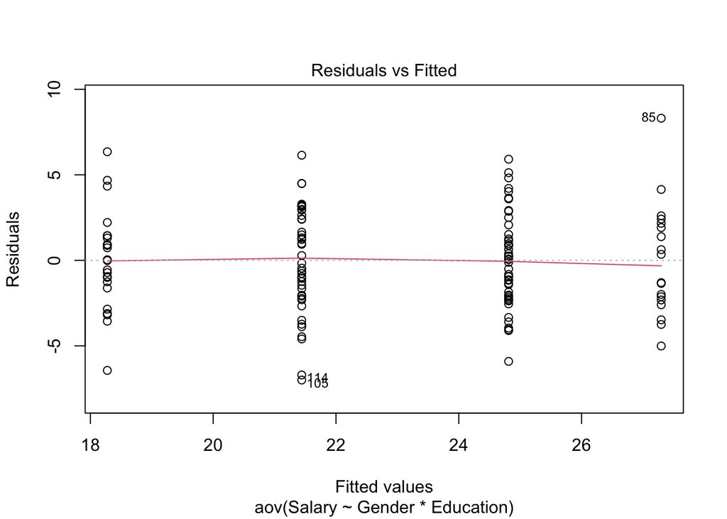

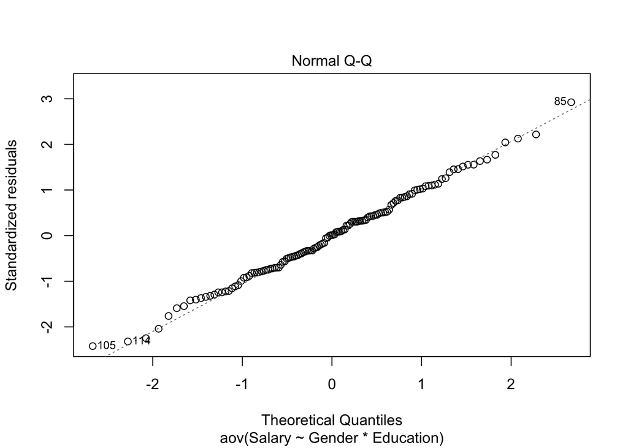

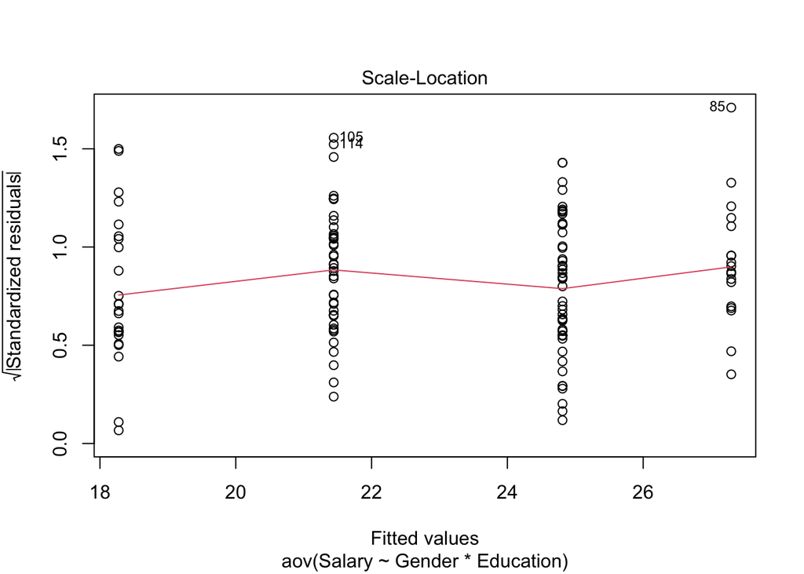

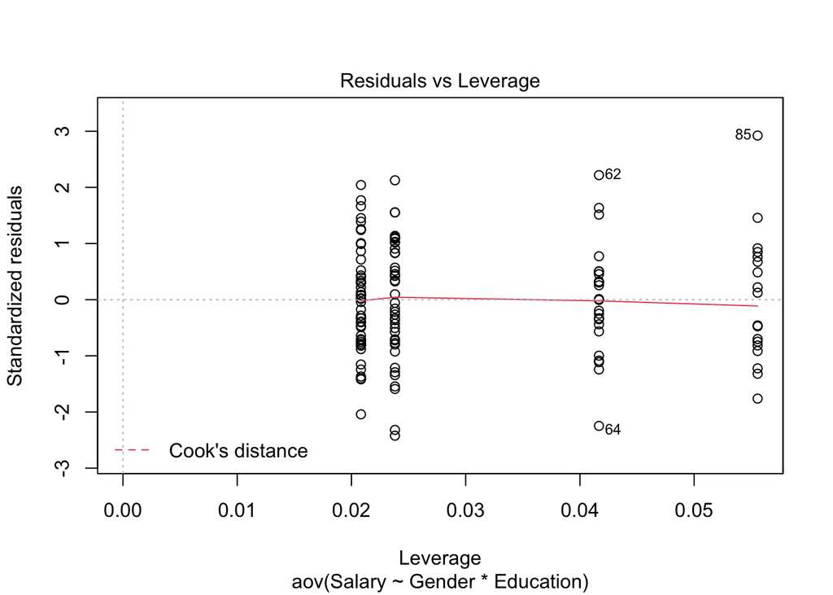

```r
plot(salary.fit)
```

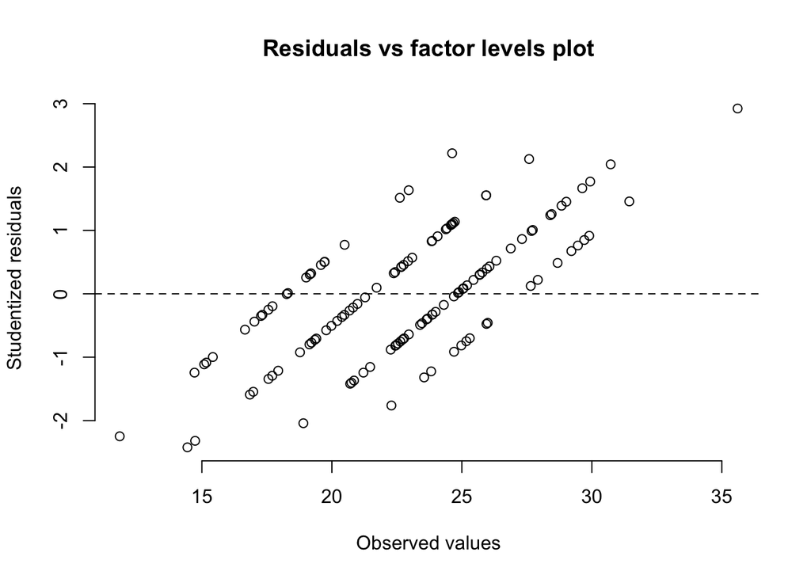

```r
#plot(res,fitted(salary.fit),
#     xlab="Fitted values",
#     ylab="Studentized residuals",
#     main="Residuals vs fitted values plot")
#abline(h=0,lty="dashed")

plot(salary.gender.txt01$Salary ,rstandard(salary.fit), xlab="Observed values",
     ylab="Studentized residuals",
     main="Residuals vs factor levels plot",axes=F)
axis(side=1)

axis(side=2)
abline(h=0,lty="dashed")
```

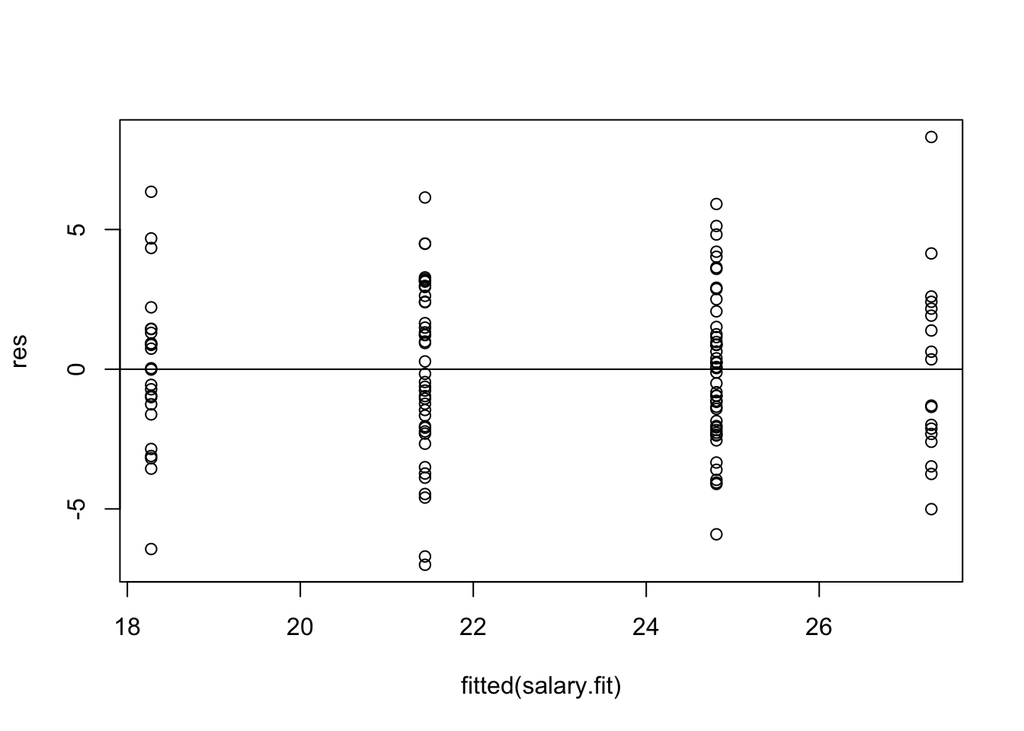

```r
res<-salary.fit$residuals
plot(fitted(salary.fit),res)
abline(0,0)
```

```r
salary.fit <- aov(Salary~Education, data = salary.gender.txt01)
summary(salary.fit) # null-hypothesis rejected
```

```
##              Df Sum Sq Mean Sq F value   Pr(>F)
## Education     1  891.9   891.9   87.24 3.49e-16 ***
## Residuals   130 1329.0    10.2
## ---
## Signif. codes:  0 '***' 0.001 '**' 0.01 '*' 0.05 '.' 0.1 ' ' 1
```

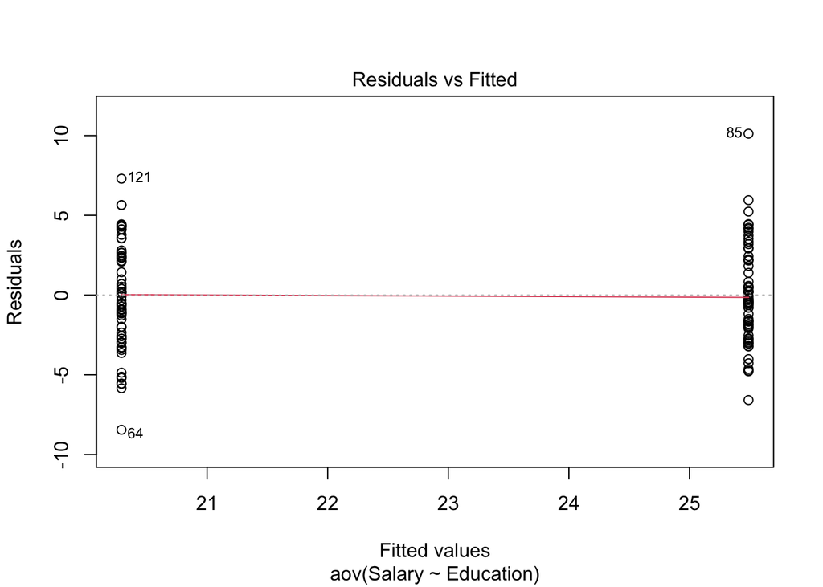

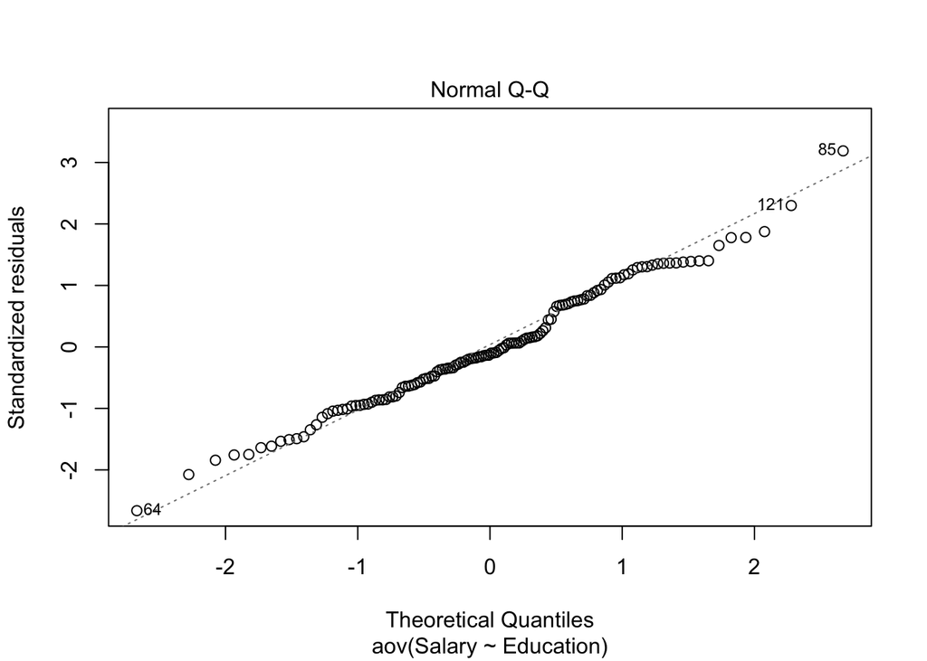

```
## hat values (leverages) are all = 0.01515152
##  and there are no factor predictors; no plot no. 5
```

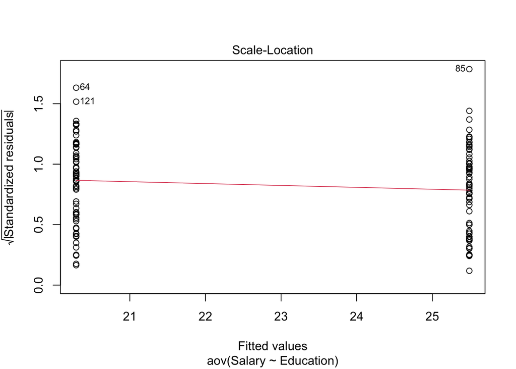

```r
plot(salary.fit)
```

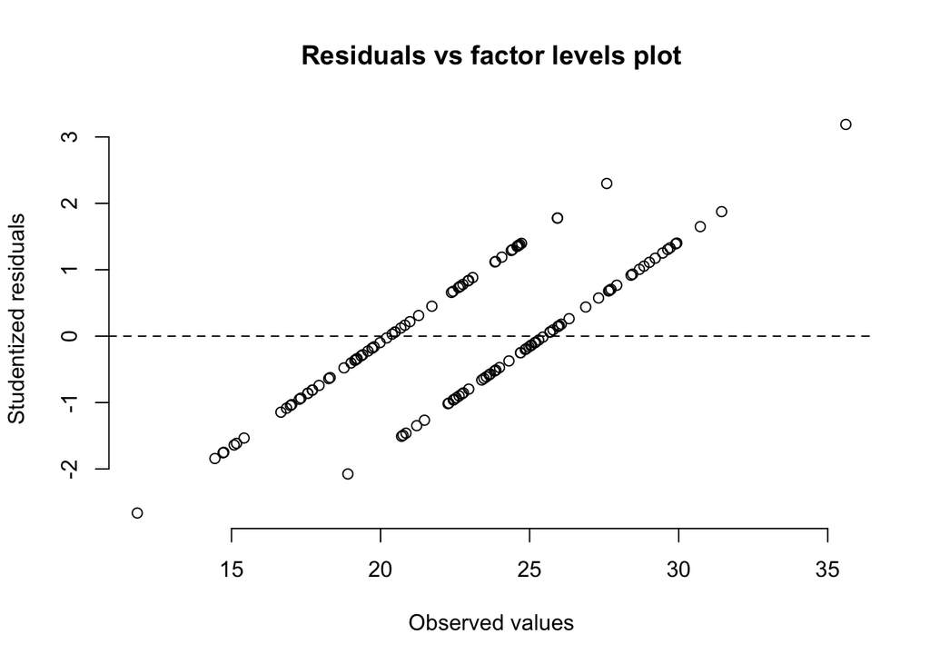

```r
#plot(res,fitted(salary.fit),
#     xlab="Fitted values",
#     ylab="Studentized residuals",
#     main="Residuals vs fitted values plot")
#abline(h=0,lty="dashed")

plot(salary.gender.txt01$Salary ,rstandard(salary.fit), xlab="Observed values",
     ylab="Studentized residuals",
     main="Residuals vs factor levels plot",axes=F)
axis(side=1)

axis(side=2)
abline(h=0,lty="dashed")
```

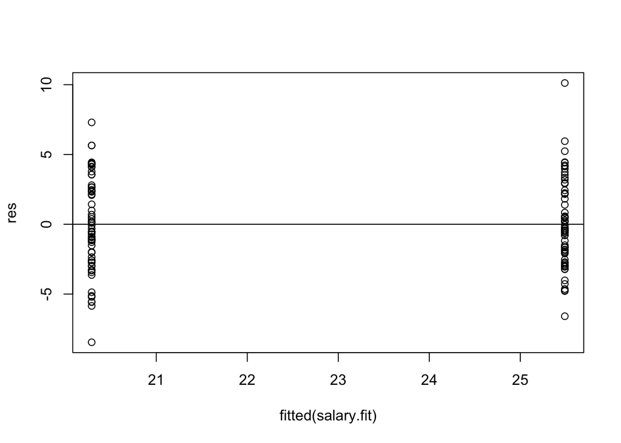

```r
res<-salary.fit$residuals
plot(fitted(salary.fit),res)
abline(0,0)
```

### Studentized residuals

```r
salary.gender.txt01$rs<-rstandard(salary.fit)
salary.gender.txt01$fit<-fitted.values(salary.fit)
salary.gender.txt01$resi<-salary.fit$residuals
#salary$Education<-as.factor(salary.gender.txt01$Education)
leveneTest(Salary~Education, data=salary.gender.txt01)
```

```
## Levene's Test for Homogeneity of Variance (center = median)
##        Df F value Pr(>F)
## group   1  1.2333 0.2688
##       130
```

### Test for independence

```r
durbinWatsonTest(salary.fit,alternative="two.sided",
                 data=salary.gender.txt01) #independent
```

```
##  lag Autocorrelation D-W Statistic p-value
##    1      0.02727943      1.934531   0.642
##  Alternative hypothesis: rho != 0
```

### Normality

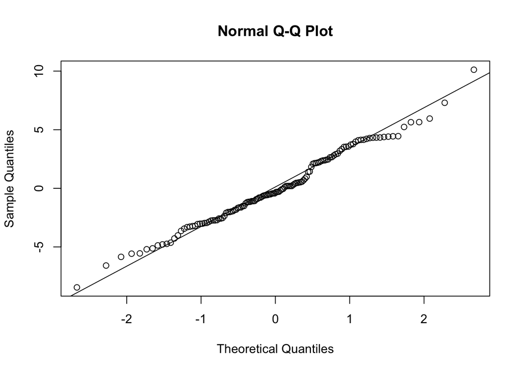

```r
qqnorm(residuals(salary.fit))
qqline(residuals(salary.fit)) #does not look normal
```

```r
shapiro.test(residuals(salary.fit)) # Passed normality test
```

```
##
##  Shapiro-Wilk normality test
##
## data:  residuals(salary.fit)
## W = 0.98811, p-value = 0.3135
```

```r
ks.test(residuals(salary.fit),"pnorm", alternative="two.sided")
```

```
##
##  One-sample Kolmogorov-Smirnov test
##
## data:  residuals(salary.fit)
## D = 0.29225, p-value = 3.225e-10
## alternative hypothesis: two-sided
```

#### Failed normality test

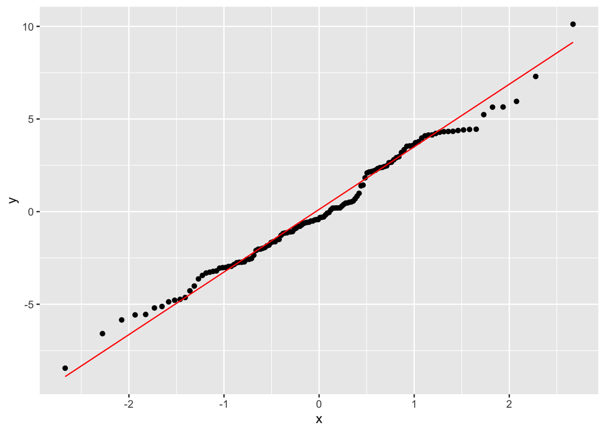

```r
ggplot(salary.gender.txt01, aes(sample=resi))+stat_qq()+stat_qq_line(color = "red")
```

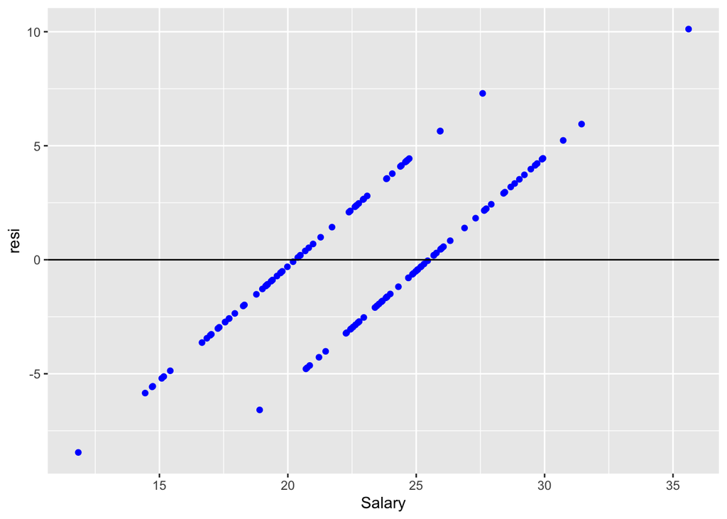

```r
#ggsave("QQLogPlot.png", path = output_path, dpi = 72,width = 12, height = 12)
ggplot(data = salary.gender.txt01, aes(y = resi, x = Salary)) +
  geom_point(col = 'blue') +
  geom_abline(slope = 0)
```

### multiple comparasion

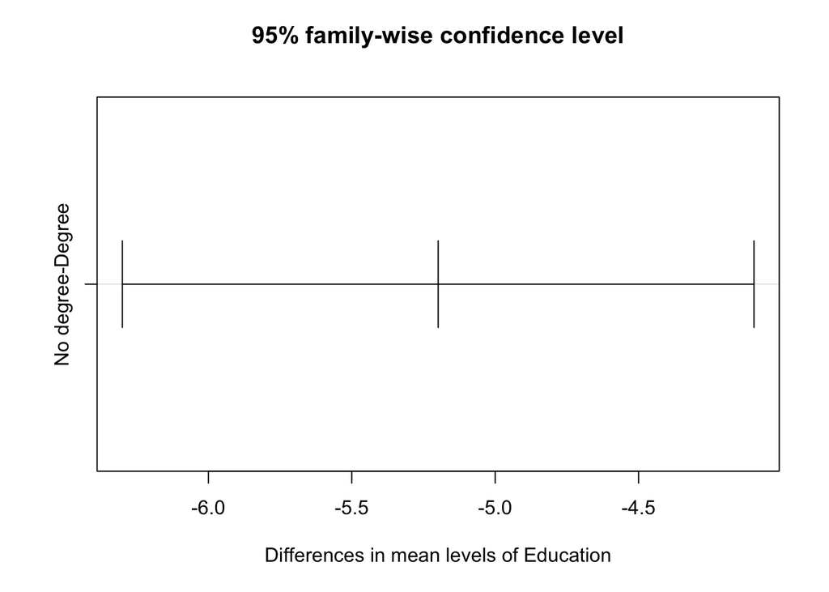

```r
TukInit <- TukeyHSD(salary.fit)
plot(TukInit)
```

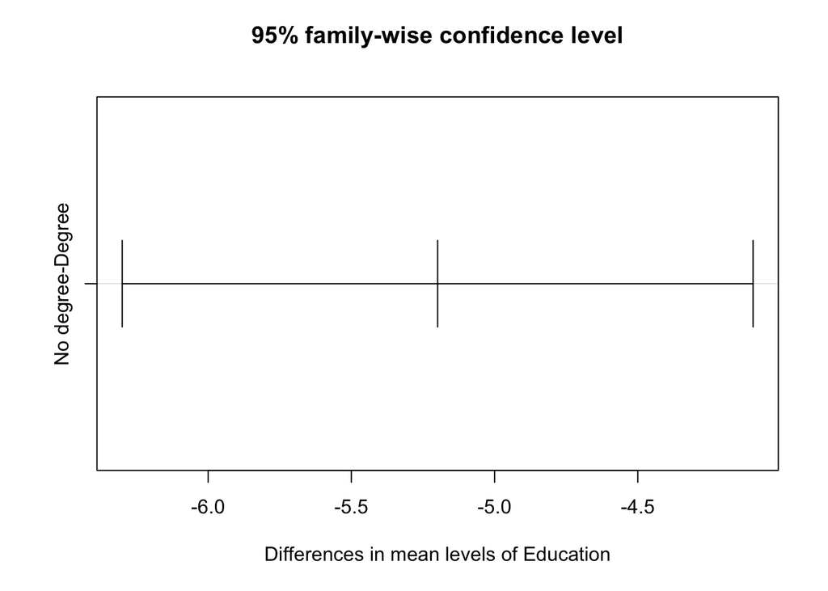

```r
scheffe <- ScheffeTest(salary.fit)
plot(scheffe)
```

```r
all_pairwise = rbind("Degree-No Degree" = c(-1, 1))
```

### find the best transformation based on boxcox procedure

```r
data.boxcox<-boxcox(salary.fit, lambda=seq(-2, 4,by=.1))
```

[figure not shown]

```r
lambda.max<-max(data.boxcox$y)
boxcox.lambda <- data.boxcox$x[data.boxcox$y==lambda.max]
boxcox.lambda
```

```
## [1] 0.969697
```

```r
salary.gender.txt01$boxcox<-salary.gender.txt01$Salary*boxcox.lambda
socialbox.fit <-aov(boxcox~f.education*f.gender, data = salary.gender.txt01)
summary(socialbox.fit)
```

```
##                       Df Sum Sq Mean Sq F value   Pr(>F)
## f.education            1  838.7   838.7 104.255  < 2e-16 ***
## f.gender               1  216.9   216.9  26.969 7.91e-07 ***
## f.education:f.gender   1    3.1     3.1   0.383    0.537
## Residuals            128 1029.7     8.0
## ---
## Signif. codes:  0 '***' 0.001 '**' 0.01 '*' 0.05 '.' 0.1 ' ' 1
```

```r
leveneTest(boxcox~Education, data=salary.gender.txt01)
```

```
## Levene's Test for Homogeneity of Variance (center = median)
##        Df F value Pr(>F)
## group   1  1.2333 0.2688
##       130
```

```r
bptest(salary.fit)
```

```
##
##  studentized Breusch-Pagan test
##
## data:  salary.fit
## BP = 0.57714, df = 1, p-value = 0.4474
```

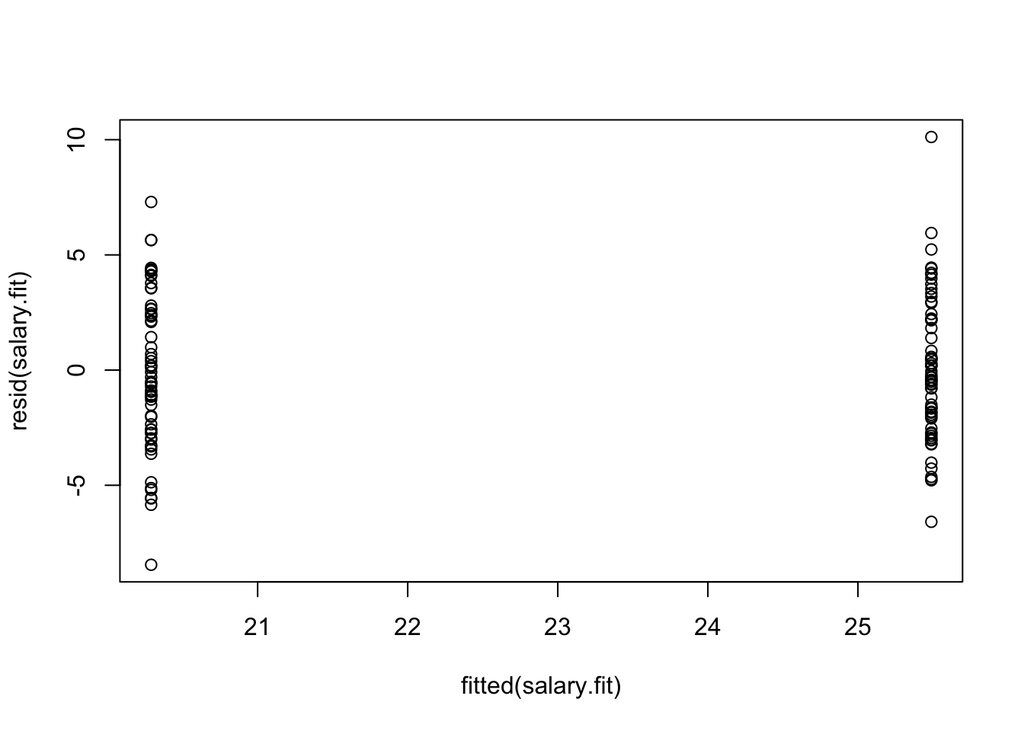

```r
plot(fitted(salary.fit),resid(salary.fit))
```